# The Analysis of The NOAA Storm Data

Ayako Nagao

7/12/2022

### 1.Synopsis

In this report, we analyze the NOAA Storm Database about the damages that severe weather events caused across the United States to answer below questions,

1. Which types of severe weather events are most harmful with respect to population health?
2. Which types of severe weather events have the greatest economic consequences?

We will find out which severe weather events are attributed to higher fatalities/injuries or greater damages to the crops/properties, so that readers can conduct further analyses and take appropriate prevention measures for those events.

### 2.Data Processing

In this section, we load the raw data, subset and alter some columns to make the data ready for analyses.

First, we load the data.

```r
url <- 'https://d396qusza40orc.cloudfront.net/repdata%2Fdata%2FStormData.csv.bz2'
download.file(url,'stormdata.csv')
data <- read.csv('stormdata.csv')
nrows <- dim(data)[1]
ncols <- dim(data)[2]
```

The data has 902297 observations and 37 features.

The first 3 rows of data:

```r
head(data,3)
```

```
##   STATE__          BGN_DATE BGN_TIME TIME_ZONE COUNTY COUNTYNAME STATE  EVTYPE
## 1       1 4/18/1950 0:00:00     0130       CST     97     MOBILE    AL TORNADO
## 2       1 4/18/1950 0:00:00     0145       CST      3    BALDWIN    AL TORNADO
## 3       1 2/20/1951 0:00:00     1600       CST     57    FAYETTE    AL TORNADO
##   BGN_RANGE BGN_AZI BGN_LOCATI END_DATE END_TIME COUNTY_END COUNTYENDN
## 1         0                                               0         NA
## 2         0                                               0         NA
## 3         0                                               0         NA
##   END_RANGE END_AZI END_LOCATI LENGTH WIDTH F MAG FATALITIES INJURIES PROPDMG
## 1         0                      14.0   100 3   0          0       15    25.0
## 2         0                       2.0   150 2   0          0        0     2.5
## 3         0                       0.1   123 2   0          0        2    25.0
##   PROPDMGEXP CROPDMG CROPDMGEXP WFO STATEOFFIC ZONENAMES LATITUDE LONGITUDE
## 1          K       0                                         3040      8812
## 2          K       0                                         3042      8755
## 3          K       0                                         3340      8742
##   LATITUDE_E LONGITUDE_ REMARKS REFNUM
## 1       3051       8806              1
## 2          0          0              2
## 3          0          0              3
```

Subset the columns we need,

```r
# Remove unnecessary columns
library(dplyr)
data <- select(data,c('STATE__',"STATE","BGN_DATE",'EVTYPE',"LENGTH","WIDTH","F","MAG","FATALITIES","INJURIES","PROPDMG","PROPDMGEXP","CROPDMG","CROPDMGEXP","REMARKS"))
```

Subset the observation we need. (we only need the observation which caused fatalities/injuries or damages to crops/properties. Thus remove the observations where all of those records equal to zero.)

```r
# remove data with ALL FATALITIES/INJURIES/CROPDMG/PROPDMG == 0

noDmgLogical <- (data$FATALITIES == 0)&
  (data$INJURIES == 0)&
  (data$PROPDMG == 0)&
  (data$CROPDMG == 0)
# Check if above logic subset all-zero-observations
colSums(data[noDmgLogical,c("FATALITIES","INJURIES","PROPDMG","CROPDMG")])
```

```
## FATALITIES   INJURIES    PROPDMG    CROPDMG
##          0          0          0          0
```

```r
# Subset data opposite of above logic
data <- subset(data, !(noDmgLogical))
nrows <- dim(data)[1]
ncols <- dim(data)[2]
```

It resulted in 254633 observations and 15 columns.

Next, in order to get the amount of damage to the crops and properties, we need to calculate actual values. The total amounts can be calculated by multiplying PROPDMG/CROPDMG columns by PROPDMGEXP/CROPDMGEXP columns respectively where multipliers are coded in alphabets(B for Billions,M for Millions and so on). Thus, after changing alphabets to multipliers in numbers, calculate values and make new columns.  
(I referenced the report [How To Handle Exponent Value of PROPDMGEXP and CROPDMGEXP](https://rstudio-pubs-static.s3.amazonaws.com/58957_37b6723ee52b455990e149edde45e5b6.html) for the clarification.)

```r
## Difine exponent column handling function
expFunc <- function(x){
  if ((x=='B') | (x=='b')) {x <- 1e+9
  }else if ((x=='M') | (x=='m')){x <- 1e+6
  }else if((x=='K') | (x=='k')){x <- 1e+3
  }else if((x=='H') | (x=='h')){x <- 1e+2
  }else if(x %in% as.character(0:8)){x <- 1e+1
  }else{x <- 1}
}

# Change alphabets to multiplier for CROPDMGEXP
data$CROPDMGEXP <- sapply(data$CROPDMGEXP,expFunc)

# Make a new column for actual damage
data <- mutate(data, totCropDmg=CROPDMG * CROPDMGEXP)

# Repeat the same process for PROPDMGEXP
data$PROPDMGEXP <- sapply(data$PROPDMGEXP, expFunc)
data <- mutate(data, totPropDmg=PROPDMG*PROPDMGEXP)
```

Now, the most important task in this data preprocessing phase is to organize the EVTYPE(event types) column. The number of official event types are 48. But if we count all unique values in this column, they are 488 at this point. It is due to the mistakes in spelling or being coded with own words. In order to compare all 48 event types, we have to assign incorrect event types to the official ones.

Steps for Assigning incorrect EVTYPE to Official EVTYPE:  
Change all values to upper cases.(It erase the difference between upper cases and lower cases.) >> Load the official event type categories, (It was copied from the documentation in PDF file.) and change them also in upper cases. >> List the event types which do not match with the official event types. >> check the pattern and use the grepl function to correct them together, if it was not sure which categories the values are pointing, read REMARKS and decide which events they possibly belong to.

```r
# Change EVTYPE column to upper cases
data$EVTYPE <- toupper(data$EVTYPE)

# Load the official 48 EVTYPE
library(kableExtra)
url2 <- 'https://raw.githubusercontent.com/belanello/storm_data/main/events.txt'
events <- read.table(url2,sep = '\n')
events <- toupper(events$V1)
# display official event list
kbl(matrix(events, nrow=16,dimnames =NULL),
    caption='Table.1: Official Event Types',type='html')  %>%    kable_styling(latex_options = 'hold_position',font_size=10)
```

Table.1: Official Event Types

| ASTRONOMICAL LOW TIDE | FUNNEL CLOUD | MARINE THUNDERSTORM WIND |
| --- | --- | --- |
| AVALANCHE | FREEZING FOG | RIP CURRENT |
| BLIZZARD | HAIL | SEICHE |
| COASTAL FLOOD | HEAT | SLEET |
| COLD/WIND CHILL | HEAVY RAIN | STORM SURGE/TIDE |
| DEBRIS FLOW | HEAVY SNOW | STRONG WIND |
| DENSE FOG | HIGH SURF | THUNDERSTORM WIND |
| DENSE SMOKE | HIGH WIND | TORNADO |
| DROUGHT | HURRICANE (TYPHOON) | TROPICAL DEPRESSION |
| DUST DEVIL | ICE STORM | TROPICAL STORM |
| DUST STORM | LAKE-EFFECT SNOW | TSUNAMI |
| EXCESSIVE HEAT | LAKESHORE FLOOD | VOLCANIC ASH |
| EXTREME COLD/WIND CHILL | LIGHTNING | WATERSPOUT |
| FLASH FLOOD | MARINE HAIL | WILDFIRE |
| FLOOD | MARINE HIGH WIND | WINTER STORM |
| FROST/FREEZE | MARINE STRONG WIND | WINTER WEATHER |

```r
# List the event types which do not match with the official event types
notInListEvents <- unique(data[!(data$EVTYPE %in% events),'EVTYPE'])
notInListEventsCounts <- length(notInListEvents)
head(notInListEvents)
```

```
## [1] "TSTM WIND"                 "ICE STORM/FLASH FLOOD"
## [3] "HURRICANE OPAL/HIGH WINDS" "THUNDERSTORM WINDS"
## [5] "HURRICANE ERIN"            "HURRICANE OPAL"
```

In total, 401 events are unlisted.

```r
# Correct typos or change them to official expressions of events

data$EVTYPE[grepl("^\\s*TSTM WIND",data$EVTYPE)] <- "THUNDERSTORM WIND"
data$EVTYPE[grepl("^HURRICANE",data$EVTYPE)] <- "HURRICANE (TYPHOON)"
data$EVTYPE[grepl("^THUNDERSTORM",data$EVTYPE)] <- "THUNDERSTORM WIND"
data$EVTYPE[grepl("FLASH FLOOD",data$EVTYPE)] <- "FLASH FLOOD"
data$EVTYPE[grepl("TORNDAO",data$EVTYPE)|
              grepl('TORNADO',data$EVTYPE)] <- "TORNADO"
data$EVTYPE[grepl("^HIGH WIND",data$EVTYPE)] <- "HIGH WIND"
data$EVTYPE[grepl("^WIND",data$EVTYPE)|
              grepl("^HIGH$",data$EVTYPE)] <- "HIGH WIND"
data$EVTYPE[grepl("^HEAVY RAIN",data$EVTYPE)] <- "HEAVY RAIN"
data$EVTYPE[grepl("LIGHTNING",data$EVTYPE)] <- "LIGHTNING"
data$EVTYPE[grepl("COLD",data$EVTYPE)&
                     !grepl("EXTREME",data$EVTYPE)&
                     !grepl('SNOW',data$EVTYPE)] <- "COLD/WIND CHILL"
data$EVTYPE[grepl("^FLOOD",data$EVTYPE)&
         !grepl("FLASH",data$EVTYPE)] <- "FLOOD"
data$EVTYPE[grepl("EXTREME COLD",data$EVTYPE)|
              grepl("HYPOTHERMIA" ,data$EVTYPE)|
              grepl("LOW TEMPERATURE",data$EVTYPE)] <- "EXTREME COLD/WIND CHILL"
data$EVTYPE[grepl("FREEZE",data$EVTYPE)] <- "FROST/FREEZE"

# Flood has different categories so do Not include other flood categories
data$EVTYPE[grepl("FLOOD",data$EVTYPE)&
                   !grepl("FLASH",data$EVTYPE)&
                     !grepl("COSTAL",data$EVTYPE)&
                     !grepl("LAKESHORE",data$EVTYPE)&
                     !grepl("COASTAL",data$EVTYPE)&
                     !grepl("LAKE",data$EVTYPE)] <-"FLOOD"

data$EVTYPE[grepl("MARINE MISHAP",data$EVTYPE)] <- "MARINE HIGH WIND"
data$EVTYPE[(grepl("^HIGH",data$EVTYPE)& !grepl('WIND',data$EVTYPE)&!grepl("^HIGH$",data$EVTYPE))|
              grepl("HEAVY SEAS",data$EVTYPE)] <- "HIGH SURF"

data$EVTYPE[grepl("SEVERE TURBULENCE",data$EVTYPE)] <- "THUNDERSTORM WIND"
data$EVTYPE[grepl("SNOW",data$EVTYPE)&
                     !(grepl('LAKE',data$EVTYPE))] <- "HEAVY SNOW"
data$EVTYPE[grepl("APACHE COUNTY",data$EVTYPE)] <- "THUNDERSTORM WIND"
data$EVTYPE[(grepl("TUNDERSTORM",data$EVTYPE)|
                  grepl("^TH.+M",data$EVTYPE)|
                  grepl("SEVERE TH.+M",data$EVTYPE))&
                !grepl("MARINE THUNDERSTORM WIND",data$EVTYPE)] <- "THUNDERSTORM WIND"
data$EVTYPE[grepl("TYPHOON",data$EVTYPE)] <- "HURRICANE (TYPHOON)"
data$EVTYPE[grepl("GUSTY",data$EVTYPE)] <- "STRONG WIND"
data$EVTYPE[grepl("LAKE.+SNOW",data$EVTYPE)] <- "LAKE-EFFECT SNOW"
data$EVTYPE[grepl("HAIL",data$EVTYPE)&
                     !grepl('MARINE',data$EVTYPE)] <- "HAIL"
data$EVTYPE[grepl("SLIDE",data$EVTYPE)] <- "DEBRIS FLOW"
data$EVTYPE[grepl("TROPICAL",data$EVTYPE)&
                     !grepl('DEPRESSION',data$EVTYPE)] <- "TROPICAL STORM"
data$EVTYPE[grepl("RAIN",data$EVTYPE)] <- "HEAVY RAIN"
data$EVTYPE[grepl("FOG",data$EVTYPE)&
              !grepl('FREEZING',data$EVTYPE)] <- "DENSE FOG"
data$EVTYPE[grepl("COASTAL FLOODING",data$EVTYPE)|
                     grepl('COASTAL FLOODING/EROSION',data$EVTYPE)] <- "COASTAL FLOOD"
data$EVTYPE[grepl("HIGH.+WINDS$",data$EVTYPE)] <- "HIGH WIND"
data$EVTYPE[grepl("FIRE",data$EVTYPE)] <- "WILDFIRE"
data$EVTYPE[grepl("ICE",data$EVTYPE)&
                     !grepl("STORM",data$EVTYPE)] <- "FROST/FREEZE"
data$EVTYPE[grepl("FROST",data$EVTYPE)|
                      grepl("GLAZE",data$EVTYPE)|
                      grepl("ICY ROADS",data$EVTYPE)|
                      grepl("EARLY FROST",data$EVTYPE)] <- "FROST/FREEZE"
data$EVTYPE[grepl("DROUGHT",data$EVTYPE)] <- "DROUGHT"
data$EVTYPE[(grepl("HEAT",data$EVTYPE)&
                     grepl('EX',data$EVTYPE))|
              grepl("HYPERTHERMIA/EXPOSURE",data$EVTYPE)] <- "EXCESSIVE HEAT"
data$EVTYPE[grepl("CHILL",data$EVTYPE)&
                     grepl('EX',data$EVTYPE)] <- "EXTREME COLD/WIND CHILL"
data$EVTYPE[grepl("FLOOD",data$EVTYPE)&
                     grepl('FLASH',data$EVTYPE)] <- "FLASH FLOOD"
data$EVTYPE[grepl("SURF",data$EVTYPE)|
              grepl("ROGUE WAVE",data$EVTYPE)] <- "HIGH SURF"
data$EVTYPE[grepl("WINTER",data$EVTYPE)&
                     !grepl('STORM',data$EVTYPE)] <- "WINTER WEATHER"
data$EVTYPE[grepl("BLIZZARD",data$EVTYPE)] <- "BLIZZARD"
data$EVTYPE[(grepl("WIN[^DG].+",data$EVTYPE)|
                      grepl('COOL',data$EVTYPE)|
                      grepl('FREEZING\\s[^F]',data$EVTYPE))&
                     !grepl('STORM',data$EVTYPE)] <- "WINTER WEATHER"
data$EVTYPE[grepl("HEAVY\\s[PMS][^NUEW]'",data$EVTYPE)|
                     grepl("EXCESSIVE WETNESS",data$EVTYPE)|
                     grepl("PRECIP",data$EVTYPE)] <- "HEAVY RAIN"
data$EVTYPE[grepl("^[^MHST].+WIN[DS]$",data$EVTYPE)|
                     grepl('FORCE',data$EVTYPE)|
              grepl("DRY MIRCOBURST WINDS",data$EVTYPE)] <- "STRONG WIND"
data$EVTYPE[grepl("URBAN",data$EVTYPE)] <- "FLOOD"
data$EVTYPE[grepl("MICROBURST",data$EVTYPE)] <- "STRONG WIND"
data$EVTYPE[grepl("COASTAL.+[N]$",data$EVTYPE)] <- "COASTAL FLOOD"
data$EVTYPE[grepl("HEAT WAVE",data$EVTYPE)|
                     grepl("RECORD HEAT",data$EVTYPE)] <- "EXCESSIVE HEAT"
data$EVTYPE[grepl("WARM",data$EVTYPE)] <- "HEAT"
data$EVTYPE[grepl("WINTER STORMS",data$EVTYPE)] <- "WINTER STORM"
data$EVTYPE[grepl("STRONG WINDS",data$EVTYPE)] <- "STRONG WIND"
data$EVTYPE[grepl("RIP CURRENTS",data$EVTYPE)] <- "RIP CURRENT"
data$EVTYPE[grepl("WATERSPOUT-",data$EVTYPE)] <- "WATERSPOUT"
data$EVTYPE[grepl("TSTMW",data$EVTYPE)] <- "THUNDERSTORM WIND"
data$EVTYPE[grepl("STORM SURGE",data$EVTYPE)|
              grepl("COASTAL SURGE",data$EVTYPE)] <- "STORM SURGE/TIDE"
data$EVTYPE[grepl("LIG.+G",data$EVTYPE)] <- "LIGHTNING"
data$EVTYPE[grepl("HEAVY SWELLS",data$EVTYPE)|
                     grepl("ROUGH SEAS",data$EVTYPE)] <- "HIGH SURF"
data$EVTYPE[grepl("NON-SEVERE WIND DAMAGE",data$EVTYPE)|
                     grepl("BLOWING DUST",data$EVTYPE)] <- "STRONG WIND"
data$EVTYPE[grepl("MARINE TSTM WIND",data$EVTYPE)] <- "MARINE THUNDERSTORM WIND"
data$EVTYPE[grepl("LANDSPOUT",data$EVTYPE)] <- "TORNADO"
data$EVTYPE[grepl("DOWNBURST",data$EVTYPE)] <- "STRONG WIND"
data$EVTYPE[grepl("COASTAL STORM",data$EVTYPE)] <- "MARINE THUNDERSTORM WIND"
data$EVTYPE[grepl("ASTRONOMICAL HIGH TIDE",data$EVTYPE)] <- "ASTRONOMICAL LOW TIDE"
data$EVTYPE[grepl("BEACH EROSION",data$EVTYPE)] <- "DEBRIS FLOW"
data$EVTYPE[grepl("RAPIDLY RISING WATER",data$EVTYPE)] <- "FLOOD"
data$EVTYPE[grepl("DROWNING",data$EVTYPE)] <- "HEAVY RAIN"
data$EVTYPE[grepl("AVALANCE",data$EVTYPE)] <- "AVALANCHE"
data$EVTYPE[grepl("HEAVY MIX",data$EVTYPE)] <- "HEAVY SNOW"
data$EVTYPE[grepl("COASTALSTORM",data$EVTYPE)|
              grepl("HEAVY SHOWER",data$EVTYPE)] <- "HEAVY RAIN"
data$EVTYPE[grepl("SLEET/ICE STORM",data$EVTYPE)] <- "SLEET"
data$EVTYPE[grepl("LAKE FLOOD",data$EVTYPE)] <- "LAKESHORE FLOOD"
data$EVTYPE[grepl("LANDSLUMP",data$EVTYPE)] <- "DEBRIS FLOW"
data$EVTYPE[grepl("MARINE ACCIDENT",data$EVTYPE)] <- "HIGH SURF"
data$EVTYPE[grepl("DAM BREAK",data$EVTYPE)] <- "HEAVY RAIN"
data$EVTYPE[grepl("GUSTNADO",data$EVTYPE)] <- "THUNDERSTORM WIND"
data$EVTYPE[grepl("DUST DEVIL WATERSPOUT",data$EVTYPE)] <- "DUST DEVIL"

# remove '?' EVTYPE since no information for weather
data <- subset(data, EVTYPE!='?')

# for "OTHER" type, need to look up REMARKS column
# get the row index and read all the REMARKS
rownames(data[data$EVTYPE=='OTHER',])
```

```
##  [1] "249470" "296122" "298603" "298604" "298605" "298606" "298607" "298608"
##  [9] "298609" "298610" "298611" "298612" "298613" "298614" "298615" "298616"
## [17] "298617" "298618" "298619" "298620" "298621" "298622" "298623" "298624"
## [25] "298625" "298626" "298627" "298628" "298629" "298630" "298631" "298632"
## [33] "399112" "435359"
```

```r
# there were only 3 possible event types. Assign them using row index.
data["249470",'EVTYPE'] <- "AVALANCHE"
data[c("296122","399112","435359"),'EVTYPE'] <- "DUST DEVIL"
data[c("298603","298604","298605","298606","298607","298608","298609",
       "298610", "298611", "298612", "298613", "298614", "298615",
       "298616", "298617", "298618","298619", "298620", "298621",
       "298622" ,"298623", "298624", "298625", "298626", "298627",
       "298628", "298629", "298630", "298631", "298632"),'EVTYPE'] <- "HEAVY RAIN"

# Unlisted events down to 0....!!!!
unique(data$EVTYPE[!(data$EVTYPE %in% events)])
```

```
## character(0)
```

```r
# Change BGN_DATE column to Date class
library(lubridate)
date <- gsub('/','-',data$BGN_DATE); date <- gsub(' 0:00:00','',date)

# Change class of BGN_DATE and Make a new column for YEAR
data <- mutate(data, BGN_DATE=mdy(date),YEAR=year(BGN_DATE))

before <- dim(data)[1]
# filter the data only after 1993
data <- filter(data, YEAR >= '1993')
after <- dim(data)[1]
```

Now data has only records from 1993 to 2011. The number of records reduced to 227256 from 254632 .

And lastly, make new columns of the sum of the damages to make an analysis easier.

```r
data <- mutate(data,
               totFatInj=FATALITIES+INJURIES,
               totCropProp=totPropDmg+totCropDmg)
```

### 3.Results

#### 3.1 The weather events that are most harmful with respect to population health

Table.2 is a list of top 5 weather events which caused the highest fatalities and injuries from 1993 to 2011. (see full list for appendix 1).

```r
healthDmgSum <- data %>%
  group_by(EVTYPE) %>%
  summarize(Fatalities=sum(FATALITIES),Injuries=sum(INJURIES),Total=sum(totFatInj)) %>%
  arrange(desc(Total))

Rank <- 1:5
kbl(cbind(Rank,healthDmgSum[1:5,]), caption='Table.2: Top 5 Events Recorded Highest Fatalities/Injuries (Descending order of Total)',
             type='html')  %>%
  kable_styling(latex_options = 'hold_position',full_width=F,position='left') %>%
  column_spec(2,bold=T) %>%
  column_spec(5,bold=T)
```

Table.2: Top 5 Events Recorded Highest Fatalities/Injuries (Descending order of Total)

| Rank | EVTYPE | Fatalities | Injuries | Total |
| --- | --- | --- | --- | --- |
| 1 | TORNADO | 1649 | 23371 | 25020 |
| 2 | EXCESSIVE HEAT | 2196 | 7109 | 9305 |
| 3 | FLOOD | 513 | 6874 | 7387 |
| 4 | THUNDERSTORM WIND | 448 | 6182 | 6630 |
| 5 | LIGHTNING | 817 | 5232 | 6049 |

Figure.1. is the graph of total fatalities/injuries by year for each top 5 weather events.

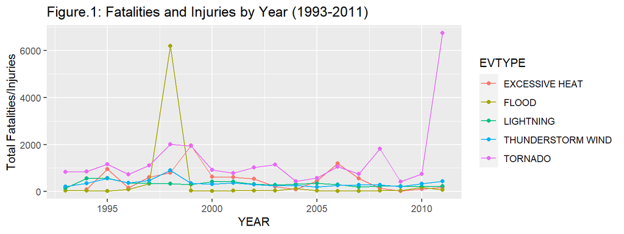

```r
library(ggplot2)
top5healthDmg <- healthDmgSum$EVTYPE[1:5]

PlotHealth <- data %>%
  select(c(YEAR,EVTYPE,totFatInj)) %>%
  filter(EVTYPE %in% top5healthDmg) %>%
  group_by(YEAR,EVTYPE) %>%
  summarize(YEARLY=sum(totFatInj))

g <- ggplot(PlotHealth,aes(x=YEAR,y=YEARLY,color=EVTYPE))
g <- g + geom_point() + geom_line()
g <- g + labs(title='Figure.1: Fatalities and Injuries by Year (1993-2011)',
          y='Total Fatalities/Injuries')
g
```

- TORNADO has the highest figure in the records, especially in 2011, 77% of the total fatalities/injuries in this year were caused by TORNADO.
- The EXCESSIVE HEAT has the highest fatalities among all the events.
- The number of the fatalities/injuries by FLOOD were relatively low except 1998. The figure in this year was nearly 84% of all the fatalities/injuries caused by Flood in the record, which means the this high figure is due to the record of this single year.

#### 3.2 The weather events having the greatest economic consequences

Table.3 is a list of top 5 weather events which caused the greatest damages to crops and properties from 1993 to 2011. (see full list for appendix 2)

```r
library(scales)
dollarFormat <- function(x) dollar(x)
economicDmgSum <- data %>%
  group_by(EVTYPE) %>%
  summarize('Crop Damage'=sum(totCropDmg),
            'Property Damage'=sum(totPropDmg),
            Total=sum(totCropProp)) %>%
  arrange(desc(Total)) %>%
  mutate_if(is.numeric,dollarFormat)

Rank <- 1:5
kbl(cbind(Rank,economicDmgSum[1:5,]),
    align=c('c','l','r','r','r'),
    caption='Table.3: Top 5 Events Recorded Highest Damages to Crops/Properties (Descending order of Total)',
             type='html')  %>%
  kable_styling(latex_options = 'hold_position',full_width=F,position='left') %>%
  column_spec(2,bold=T)%>%
  column_spec(5,bold=T)
```

Table.3: Top 5 Events Recorded Highest Damages to Crops/Properties (Descending order of Total)

| Rank | EVTYPE | Crop Damage | Property Damage | Total |
| --- | --- | --- | --- | --- |
| 1 | FLOOD | $10,855,961,050 | $150,234,461,439 | $161,090,422,489 |
| 2 | HURRICANE (TYPHOON) | $5,516,117,800 | $85,356,410,010 | $90,872,527,810 |
| 3 | STORM SURGE/TIDE | $855,000 | $47,965,224,000 | $47,966,079,000 |
| 4 | TORNADO | $417,462,960 | $27,994,909,080 | $28,412,372,040 |
| 5 | HAIL | $3,046,887,803 | $15,974,542,434 | $19,021,430,237 |

Figure.2 is the graph of total damages to crops/properties by year for each top 5 weather events.

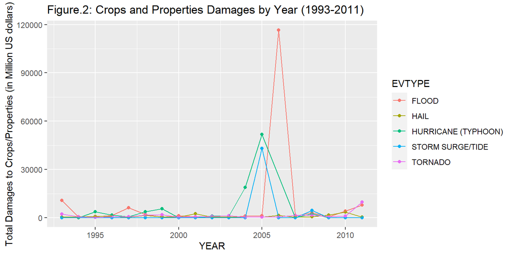

```r
top5economicDmg <- economicDmgSum$EVTYPE[1:5]

PlotEconomy <- data %>%
  select(c(YEAR,EVTYPE,totCropProp)) %>%
  filter(EVTYPE %in% top5economicDmg) %>%
  group_by(YEAR,EVTYPE) %>%
  summarize(YEARLY=sum(totCropProp)/1e+6)

g <- ggplot(PlotEconomy,aes(x=YEAR,y=YEARLY,color=EVTYPE))
g <- g + geom_point() + geom_line()
g <- g + labs(title='Figure.2: Crops and Properties Damages by Year (1993-2011)',
          y='Total Damages to Crops/Properties (in Million US dollars)')
g
```

As we can see in Figure.2, most of the economic damages to crops and properties have been caused by three events, FLOOD, HURRICANE (TYPHOON) and STORM SURGE/TIDE between 2004 and 2006.

### References

[How To Handle Exponent Value of PROPDMGEXP and CROPDMGEXP](https://rstudio-pubs-static.s3.amazonaws.com/58957_37b6723ee52b455990e149edde45e5b6.html)

Storm Data Documentation

### Appendix

1.The Full list of total Fatalities/Injuries for each event.

```r
kable(healthDmgSum,type='html') %>%
  kable_styling(font_size=10,full_width=F,position='left')
```

| EVTYPE | Fatalities | Injuries | Total |
| --- | --- | --- | --- |
| TORNADO | 1649 | 23371 | 25020 |
| EXCESSIVE HEAT | 2196 | 7109 | 9305 |
| FLOOD | 513 | 6874 | 7387 |
| THUNDERSTORM WIND | 448 | 6182 | 6630 |
| LIGHTNING | 817 | 5232 | 6049 |
| HEAT | 977 | 2119 | 3096 |
| FLASH FLOOD | 1035 | 1802 | 2837 |
| ICE STORM | 89 | 1975 | 2064 |
| HIGH WIND | 319 | 1574 | 1893 |
| WILDFIRE | 90 | 1608 | 1698 |
| WINTER STORM | 216 | 1338 | 1554 |
| HURRICANE (TYPHOON) | 135 | 1333 | 1468 |
| HEAVY SNOW | 166 | 1159 | 1325 |
| DENSE FOG | 80 | 1076 | 1156 |
| RIP CURRENT | 572 | 529 | 1101 |
| HAIL | 10 | 970 | 980 |
| BLIZZARD | 101 | 805 | 906 |
| WINTER WEATHER | 65 | 630 | 695 |
| EXTREME COLD/WIND CHILL | 319 | 260 | 579 |
| STRONG WIND | 120 | 350 | 470 |
| DUST STORM | 22 | 440 | 462 |
| HIGH SURF | 188 | 263 | 451 |
| FROST/FREEZE | 22 | 427 | 449 |
| TROPICAL STORM | 66 | 383 | 449 |
| HEAVY RAIN | 112 | 329 | 441 |
| AVALANCHE | 225 | 170 | 395 |
| COLD/WIND CHILL | 149 | 61 | 210 |
| TSUNAMI | 33 | 129 | 162 |
| DEBRIS FLOW | 44 | 55 | 99 |
| STORM SURGE/TIDE | 24 | 43 | 67 |
| MARINE THUNDERSTORM WIND | 22 | 36 | 58 |
| DUST DEVIL | 2 | 47 | 49 |
| MARINE STRONG WIND | 14 | 22 | 36 |
| WATERSPOUT | 3 | 29 | 32 |
| DROUGHT | 6 | 19 | 25 |
| MARINE HIGH WIND | 8 | 6 | 14 |
| COASTAL FLOOD | 6 | 7 | 13 |
| FUNNEL CLOUD | 0 | 3 | 3 |
| SLEET | 2 | 0 | 2 |
| ASTRONOMICAL LOW TIDE | 0 | 0 | 0 |
| DENSE SMOKE | 0 | 0 | 0 |
| FREEZING FOG | 0 | 0 | 0 |
| LAKE-EFFECT SNOW | 0 | 0 | 0 |
| LAKESHORE FLOOD | 0 | 0 | 0 |
| MARINE HAIL | 0 | 0 | 0 |
| SEICHE | 0 | 0 | 0 |
| TROPICAL DEPRESSION | 0 | 0 | 0 |
| VOLCANIC ASH | 0 | 0 | 0 |

2.The full list of total damages to the crops/properties for each event.

```r
kable(economicDmgSum,type='html') %>%
  kable_styling(font_size=10,full_width=F,position='left')
```

| EVTYPE | Crop Damage | Property Damage | Total |
| --- | --- | --- | --- |
| FLOOD | $10,855,961,050 | $150,234,461,439 | $161,090,422,489 |
| HURRICANE (TYPHOON) | $5,516,117,800 | $85,356,410,010 | $90,872,527,810 |
| STORM SURGE/TIDE | $855,000 | $47,965,224,000 | $47,966,079,000 |
| TORNADO | $417,462,960 | $27,994,909,080 | $28,412,372,040 |
| HAIL | $3,046,887,803 | $15,974,542,434 | $19,021,430,237 |
| FLASH FLOOD | $1,532,197,150 | $16,907,931,420 | $18,440,128,570 |
| DROUGHT | $13,972,621,780 | $1,046,306,000 | $15,018,927,780 |
| THUNDERSTORM WIND | $1,271,666,258 | $10,970,671,099 | $12,242,337,357 |
| ICE STORM | $5,022,113,500 | $3,944,928,310 | $8,967,041,810 |
| WILDFIRE | $403,281,630 | $8,496,628,500 | $8,899,910,130 |
| TROPICAL STORM | $694,896,000 | $7,714,390,550 | $8,409,286,550 |
| HIGH WIND | $692,661,900 | $6,074,134,763 | $6,766,796,663 |
| WINTER STORM | $27,444,000 | $6,688,997,260 | $6,716,441,260 |
| HEAVY RAIN | $949,540,200 | $3,247,288,690 | $4,196,828,890 |
| FROST/FREEZE | $1,997,061,800 | $37,117,700 | $2,034,179,500 |
| EXTREME COLD/WIND CHILL | $1,330,023,000 | $77,190,400 | $1,407,213,400 |
| HEAVY SNOW | $134,663,100 | $986,222,767 | $1,120,885,867 |
| LIGHTNING | $12,092,090 | $933,743,920 | $945,836,010 |
| BLIZZARD | $112,060,000 | $659,813,950 | $771,873,950 |
| EXCESSIVE HEAT | $502,952,000 | $18,328,750 | $521,280,750 |
| COASTAL FLOOD | $56,000 | $428,382,060 | $428,438,060 |
| HEAT | $401,471,500 | $1,797,000 | $403,268,500 |
| DEBRIS FLOW | $20,017,000 | $327,496,100 | $347,513,100 |
| STRONG WIND | $70,178,500 | $186,952,840 | $257,131,340 |
| COLD/WIND CHILL | $96,742,500 | $58,644,000 | $155,386,500 |
| TSUNAMI | $20,000 | $144,062,000 | $144,082,000 |
| HIGH SURF | $0 | $102,067,000 | $102,067,000 |
| WINTER WEATHER | $20,000,000 | $27,455,500 | $47,455,500 |
| LAKE-EFFECT SNOW | $0 | $40,682,000 | $40,682,000 |
| DENSE FOG | $0 | $22,829,500 | $22,829,500 |
| ASTRONOMICAL LOW TIDE | $0 | $9,745,000 | $9,745,000 |
| WATERSPOUT | $0 | $9,564,200 | $9,564,200 |
| DUST STORM | $3,100,000 | $5,549,000 | $8,649,000 |
| LAKESHORE FLOOD | $0 | $7,570,000 | $7,570,000 |
| MARINE THUNDERSTORM WIND | $50,000 | $5,907,400 | $5,957,400 |
| AVALANCHE | $0 | $3,771,800 | $3,771,800 |
| FREEZING FOG | $0 | $2,182,000 | $2,182,000 |
| TROPICAL DEPRESSION | $0 | $1,737,000 | $1,737,000 |
| MARINE HIGH WIND | $0 | $1,297,010 | $1,297,010 |
| SEICHE | $0 | $980,000 | $980,000 |
| DUST DEVIL | $0 | $724,630 | $724,630 |
| SLEET | $0 | $500,000 | $500,000 |
| VOLCANIC ASH | $0 | $500,000 | $500,000 |
| MARINE STRONG WIND | $0 | $418,330 | $418,330 |
| FUNNEL CLOUD | $0 | $194,600 | $194,600 |
| RIP CURRENT | $0 | $163,000 | $163,000 |
| DENSE SMOKE | $0 | $100,000 | $100,000 |
| MARINE HAIL | $0 | $4,000 | $4,000 |

3.Code used in 3.1 for observation.

```r
# SECTION 3-1 OBSERVATION OF THE FATALITIES AND INJURIES
# Calculate 2011 tornado percentage in total fatalities/injuries
data2011 <- data %>%
  filter(YEAR=='2011') %>%
  group_by(EVTYPE) %>%
  summarize(S=sum(totFatInj))

pctTornado <- round(data2011$S[data2011$EVTYPE=='TORNADO'] / sum(data2011$S),2) * 100
# Calculate flood percentage of 1998
flood1998 <- filter(data, EVTYPE=='FLOOD' & YEAR=='1998')
flood <- filter(data,EVTYPE=='FLOOD')

pct1998 <- round(sum(flood1998$totFatInj) / sum(flood$totFatInj),2)*100
```